# **Homework 4: Transfer learning with the MobileNets**

**DUE Wednesday 13 November at 4pm (both sections).**

## Instruction:

Submit your homework by publishing a notebook that cleanly displays your code, results, and plots to pdf or html. Also, be sure to answer all the reflection questions.

**For coding questions, look for filling in ########## Your code here ##########; for reflection questions, write down your answers in the "Your Answer:" text block.**

## Description:

In this homework, you will practice (1) going over the full procedure of training a neural network and (2) extending your knowledge on TF2, by implementing a transfer learning task. You will incorporate the existing [MobileNets](https://arxiv.org/abs/1704.04861) to your own network structure and to classify some new categories of images. Building and fitting the network from scratch is expensive and beyond the scope of this assignment, so you will load the MobileNets model which was pre-trained on the imagenet dataset. The version of MobileNet we're using is V2, which is a family of neural network architectures for efficient on-device image classification and related tasks.

As a general advice, please refer to the official documentations for more info in necessary: [Keras](https://keras.io/), [TF Datasets](https://www.tensorflow.org/datasets), and [TF Hub](https://www.tensorflow.org/hub).

**First, let's not forget to upgrade to TF 2.0.**

```python
!pip install --upgrade tensorflow
```

**Import modules for later usage.**

```python
import tensorflow as tf

#from tensorflow import keras
!pip install -q tensorflow tensorflow-datasets matplotlib
import matplotlib.pyplot as plt
import numpy as np
import tensorflow_datasets as tfds
import tensorflow_hub as hub

print("TF version: ",tf.__version__)
print("Keras version:",tf.keras.__version__)
```

```
TF version:  2.0.0
Keras version: 2.2.4-tf
```

## **Part 1: Download and format the data**

The data we are going to use is the [Oxford flower dataset](http://www.robots.ox.ac.uk/~vgg/data/flowers/102/) which consists of 102 categories of flowers. Each class consists of between 40 and 258 images. The images can be found [here](https://www.robots.ox.ac.uk/~vgg/data/flowers/102/categories.html).

The main difficulty of learninig from this dataset is in the large size of the classes. You may refer to [this paper](http://www.robots.ox.ac.uk/~vgg/publications/2008/Nilsback08/) for what other researchers have done with it.

### (1) Data Pre-processing

First, load the dataset from [Tensorflow Datasets](https://www.tensorflow.org/datasets/catalog/overview) and split the data into training and testing sets. How many training and testing samples do you have? Save the numbers to two variables, *num_train* and *num_test*, respectively.

```python
(train_data, test_data) = tfds.load('oxford_flowers102:2.0.0', split = ('train','test'),
                                    as_supervised=True)
```

```
Downloading and preparing dataset oxford_flowers102 (336.76 MiB) to /root/tensorflow_datasets/oxford_flowers102/2.0.0...
```

```
Shuffling and writing examples to /root/tensorflow_datasets/oxford_flowers102/2.0.0.incompleteEZZ468/oxford_flowers102-train.tfrecord
```

```
Shuffling and writing examples to /root/tensorflow_datasets/oxford_flowers102/2.0.0.incompleteEZZ468/oxford_flowers102-test.tfrecord
```

```
Shuffling and writing examples to /root/tensorflow_datasets/oxford_flowers102/2.0.0.incompleteEZZ468/oxford_flowers102-validation.tfrecord
```

```
Dataset oxford_flowers102 downloaded and prepared to /root/tensorflow_datasets/oxford_flowers102/2.0.0. Subsequent calls will reuse this data.
```

```python
# Print the number of training and testing samples

########## Your code here ##########

num_train = [i for i,_ in enumerate(train_data)][-1] + 1
num_test = [i for i,_ in enumerate(test_data)][-1] + 1
print(num_train, num_test)
```

```
1020 6149
```

Next, we would like to format all the images for the MobileNet module.

For this module, the size of the input image is fixed to height x width = 224 x 224 pixels. The input images are expected to have 3 RGB color values in the range [0, 1], following the common image input conventions (analogously to TF 1.x).

```python
# Initiate the parameters
IMG_SIZE = 224
IMG_SHAPE = (IMG_SIZE, IMG_SIZE, 3)
```

```python
# Define a function to format the data
@tf.function
def format_example(image, label):
    #print("Format example called!")
    # First, convert the data type to tf.float32
    image = tf.dtypes.cast(image, dtype=tf.float32)
    # Second, normalize the image
    image = image / 255.0
    # Third, resize the image
    image = tf.image.resize(image, (IMG_SIZE,IMG_SIZE))
    return image, label
```

```python
# Apply the above function to the previous train_data and test_data,
# to get the formatted training and testing sets, respectively.

train = train_data.map(format_example)
test = test_data.map(format_example)
```

### (2) Data Exploration

Let's plot some of the data.

```python
assert isinstance(train, tf.data.Dataset)
assert isinstance(test, tf.data.Dataset)
print(train)
print(test)
```

```
<MapDataset shapes: ((224, 224, 3), ()), types: (tf.float32, tf.int64)>
<MapDataset shapes: ((224, 224, 3), ()), types: (tf.float32, tf.int64)>
```

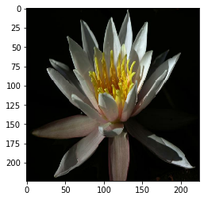

```
Label: 72
```

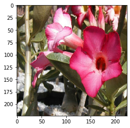

```
Label: 84
```

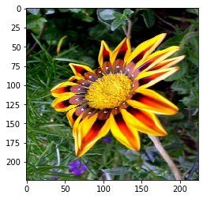

```
Label: 70
```

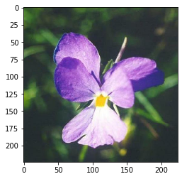

```
Label: 51
```

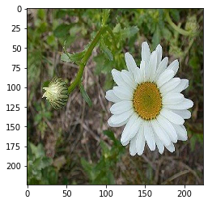

```
Label: 48
```

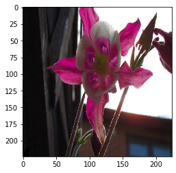

```
Label: 83
```

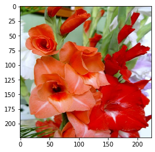

```
Label: 42
```

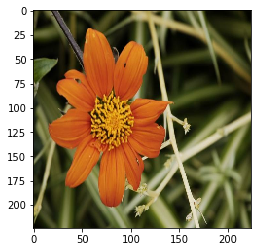

```
Label: 58
```

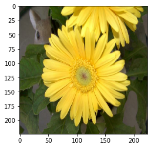

```
Label: 40
```

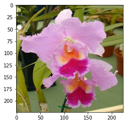

```
Label: 35
```

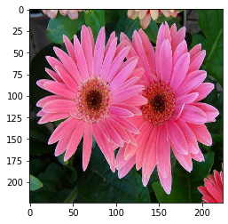

```
Label: 40
```

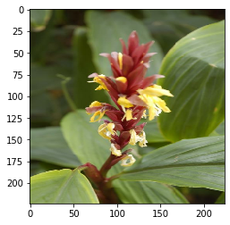

```
Label: 60
```

[3 more figures not shown]

```
Label: 87
```

```python
for example in train.take(15):  # Take first 15 examples
  image, label = example[0], example[1]
  plt.imshow(image.numpy())
  plt.pause(0.5);
  print("Label: %d" % label.numpy())
```

### **Reflection Questions:**

(1) In the data exploration stage, what is the purpose of "*assert isinstance(train, tf.data.Dataset)*"?

**Your Answer:** It checks if the class of $\texttt{train}$ and $\texttt{test}$ is $\texttt{tf.data.Dataset}$ in advance to ensure that the following process runs without error. If the class is incorrect it will stop executing following codes.

## **Part 2: Self-defined CNN**

In this section, you will define your own CNN to classify the Oxford flowers.

Recall from the tutorial, to build a neural network using tf.keras, there are three steps: defining the model, compiling the model and fitting the model. Each step should be straightforward.

After fitting the model, visualize your model in TensorBoard.

In this stage, we do not ask for a good performance. But please ensure that you obtain a trainable model with no programming bugs.

```python
# Step 1: Model definition
# Use a Keras Sequential model for defining your own CNN

# set seed for reproducibility
np.random.seed(0)

model = tf.keras.models.Sequential()
model.add(tf.keras.layers.Conv2D(32, (3,3), activation='relu', input_shape=IMG_SHAPE,
                                 padding='same'))
model.add(tf.keras.layers.MaxPool2D(2,2))
model.add(tf.keras.layers.Conv2D(32, (5,5), activation='relu'))
model.add(tf.keras.layers.MaxPool2D(2,2))
model.add(tf.keras.layers.Conv2D(32, (3,3), activation='relu'))
model.add(tf.keras.layers.MaxPool2D(2,2))
model.add(tf.keras.layers.Conv2D(32, (3,3), activation='relu'))
model.add(tf.keras.layers.MaxPool2D(2,2))
model.add(tf.keras.layers.Dropout(0.25))
model.add(tf.keras.layers.Flatten())
model.add(tf.keras.layers.Dense(256, activation='relu'))
model.add(tf.keras.layers.Dropout(0.25))
model.add(tf.keras.layers.Dense(102, activation='softmax'))

model.summary()
```

```
Model: "sequential_3"
_________________________________________________________________
Layer (type)                 Output Shape              Param #
=================================================================
conv2d_12 (Conv2D)           (None, 224, 224, 32)      896
_________________________________________________________________
max_pooling2d_12 (MaxPooling (None, 112, 112, 32)      0
_________________________________________________________________
conv2d_13 (Conv2D)           (None, 108, 108, 32)      25632
_________________________________________________________________
max_pooling2d_13 (MaxPooling (None, 54, 54, 32)        0
_________________________________________________________________
conv2d_14 (Conv2D)           (None, 52, 52, 32)        9248
_________________________________________________________________
max_pooling2d_14 (MaxPooling (None, 26, 26, 32)        0
_________________________________________________________________
conv2d_15 (Conv2D)           (None, 24, 24, 32)        9248
_________________________________________________________________
max_pooling2d_15 (MaxPooling (None, 12, 12, 32)        0
_________________________________________________________________
dropout_7 (Dropout)          (None, 12, 12, 32)        0
_________________________________________________________________
flatten_3 (Flatten)          (None, 4608)              0
_________________________________________________________________
dense_6 (Dense)              (None, 256)               1179904
_________________________________________________________________
dropout_8 (Dropout)          (None, 256)               0
_________________________________________________________________
dense_7 (Dense)              (None, 102)               26214
=================================================================
Total params: 1,251,142
Trainable params: 1,251,142
Non-trainable params: 0
_________________________________________________________________
```

```python
# Step 2: Model compilation
# Be sure to specify the optimizer, loss and metric as required

model.compile(optimizer = 'adam', loss = 'sparse_categorical_crossentropy',
              metrics = ['sparse_categorical_accuracy'])
```

```python
# Step 3: Model fitting
# Use the prepared training data to fit your CNN

model.fit(train.batch(32), epochs=10)
```

```
<tensorflow.python.keras.callbacks.History at 0x7fcf5f938828>
```

```python
model.evaluate(test.batch(1))
```

```
[8.23534532924064, 0.07074321]
```

### **Reflection Questions:**

(1) How did you choose your network structure? \ (2) Which optimizer did you use? Why? \

**Your Answer:**

(2) I use $\texttt{adam}$ since it is relatively fast computationally and is used by a lot of CNN examples online and course slide.

## **Part 3: Transfer Learning Using Pre-trained Model**

For more info about transfer learning, please look up [here](http://ronny.rest/blog/post_2017_10_13_tf_transfer_learning/). In this homework, you will practice B2, using MobileNet_V2.

### (1) Transfer learning using pre-defined features (bottleneck).

```python
MobileNet = tf.keras.applications.mobilenet_v2.MobileNetV2(input_shape=IMG_SHAPE, include_top=False, weights='imagenet')
```

```
Downloading data from https://github.com/JonathanCMitchell/mobilenet_v2_keras/releases/download/v1.1/mobilenet_v2_weights_tf_dim_ordering_tf_kernels_1.0_224_no_top.h5
```

Now you can go through the same steps to build and train the transfer learning model.

```python
# Step 1: Model definition
# Use a Keras Sequential model for defining the transfer learning model (B2 style)

np.random.seed(0)

model_transfer = tf.keras.Sequential([
                                      MobileNet,
########## Your code here ##########
tf.keras.layers.Conv2D(64, (1,1), activation='relu'),
tf.keras.layers.MaxPool2D(2,2),
tf.keras.layers.Flatten(),
tf.keras.layers.Dense(256, activation='relu'),
tf.keras.layers.Dense(102, activation='softmax')
                                      ])
```

```python
# visualize the model graphical structure
model_transfer.summary()
```

```
Model: "sequential_5"
_________________________________________________________________
Layer (type)                 Output Shape              Param #
=================================================================
mobilenetv2_1.00_224 (Model) (None, 7, 7, 1280)        2257984
_________________________________________________________________
conv2d_17 (Conv2D)           (None, 7, 7, 64)          81984
_________________________________________________________________
max_pooling2d_17 (MaxPooling (None, 3, 3, 64)          0
_________________________________________________________________
flatten_5 (Flatten)          (None, 576)               0
_________________________________________________________________
dense_10 (Dense)             (None, 256)               147712
_________________________________________________________________
dense_11 (Dense)             (None, 102)               26214
=================================================================
Total params: 2,513,894
Trainable params: 2,479,782
Non-trainable params: 34,112
_________________________________________________________________
```

```python
# This block is for Tensorboard

# Load the TensorBoard notebook extension
%load_ext tensorboard

import datetime, os
from packaging import version

# Clear any logs from previous runs
!rm -rf ./logs/

# For use of Tensorboard later
logs_base_dir = "./logs"
os.makedirs(logs_base_dir, exist_ok=True)
```

```python
# Step 2: Model compilation
# Be sure to specify the optimizer, loss and metric as required

########## Your code here ##########
model_transfer.compile(optimizer = 'adam', loss = 'sparse_categorical_crossentropy',
              metrics = ['sparse_categorical_accuracy'])
```

```python
# Step 3: Model fitting
# Use the prepared training data to fit the transfer learning model

model_transfer.fit(train.shuffle(10000).batch(32),
          epochs=5,
          verbose=2,
          callbacks=[tf.keras.callbacks.TensorBoard(log_dir=logs_base_dir, histogram_freq=1)])
```

```
32/32 - 194s - loss: 4.5453 - sparse_categorical_accuracy: 0.0608
32/32 - 181s - loss: 2.6224 - sparse_categorical_accuracy: 0.3784
32/32 - 180s - loss: 1.3066 - sparse_categorical_accuracy: 0.6343
32/32 - 181s - loss: 0.7361 - sparse_categorical_accuracy: 0.8059
32/32 - 182s - loss: 0.6022 - sparse_categorical_accuracy: 0.8333
```

```
<tensorflow.python.keras.callbacks.History at 0x7fcf67701240>
```

```python
# Step 4: Model evaluation
# Use the prepared testing data to evaluate the transfer learning model

########## Your code here ##########
model_transfer.evaluate(test.shuffle(10000).batch(32), verbose=2)
```

```
193/193 - 230s - loss: 11.8982 - sparse_categorical_accuracy: 0.0511
```

```
[11.89821339641828, 0.051065214]
```

### (2) Look at the network architecture and performance evolution in tensorboard.

```python
# Refresh TensorBoard
########## Your code here ##########
!pip install --upgrade grpcio
%tensorboard --logdir {logs_base_dir}
```

[output not shown]

[output not shown]

### (3) Fine-tune some parameters in your network to see if you can improve the performance on testing data.

```python
########## Your code here ##########

np.random.seed(0)

model_transfer_tuned = tf.keras.Sequential([
                                      MobileNet,
tf.keras.layers.Dropout(0.25), # Add dropout
tf.keras.layers.Conv2D(64, (2,2), activation='relu'),
tf.keras.layers.MaxPool2D(2,2),
tf.keras.layers.Conv2D(64, (2,2), padding='same', activation='relu'),
tf.keras.layers.Flatten(),
tf.keras.layers.Dense(256, activation='relu'),
tf.keras.layers.Dropout(0.25), # Add dropout
tf.keras.layers.Dense(102, activation='softmax')
                                      ])

model_transfer_tuned.summary()

# model compilation
model_transfer_tuned.compile(optimizer = 'adam', loss = 'sparse_categorical_crossentropy',
              metrics = ['sparse_categorical_accuracy'])

# model fitting
model_transfer_tuned.fit(train.shuffle(10000).batch(32),
          epochs=5,
          verbose=2,
          callbacks=[tf.keras.callbacks.TensorBoard(log_dir=logs_base_dir, histogram_freq=1)])

# model evaluation
np.random.seed(0)
model_transfer_tuned.evaluate(test.shuffle(10000).batch(32), verbose=2)
```

```
Model: "sequential_12"
_________________________________________________________________
Layer (type)                 Output Shape              Param #
=================================================================
mobilenetv2_1.00_224 (Model) (None, 7, 7, 1280)        2257984
_________________________________________________________________
dropout_20 (Dropout)         (None, 7, 7, 1280)        0
_________________________________________________________________
conv2d_24 (Conv2D)           (None, 6, 6, 64)          327744
_________________________________________________________________
max_pooling2d_24 (MaxPooling (None, 3, 3, 64)          0
_________________________________________________________________
conv2d_25 (Conv2D)           (None, 3, 3, 64)          16448
_________________________________________________________________
flatten_12 (Flatten)         (None, 576)               0
_________________________________________________________________
dense_24 (Dense)             (None, 256)               147712
_________________________________________________________________
dropout_21 (Dropout)         (None, 256)               0
_________________________________________________________________
dense_25 (Dense)             (None, 102)               26214
=================================================================
Total params: 2,776,102
Trainable params: 2,741,990
Non-trainable params: 34,112
_________________________________________________________________
32/32 - 179s - loss: 4.2455 - sparse_categorical_accuracy: 0.1010
32/32 - 171s - loss: 2.6588 - sparse_categorical_accuracy: 0.3843
32/32 - 170s - loss: 1.7319 - sparse_categorical_accuracy: 0.5529
32/32 - 172s - loss: 1.1918 - sparse_categorical_accuracy: 0.6853
32/32 - 171s - loss: 0.9753 - sparse_categorical_accuracy: 0.7333
193/193 - 218s - loss: 13.8428 - sparse_categorical_accuracy: 0.0158
```

```
[13.84284315949277, 0.015774922]
```

### **Reflection Questions:**

(1) Briefly explain the network structure of MobileNet and how is it different from other models? \ (2) In your experiment, which parameter(s) is the network most sensitive to? Can you briefly reason why? \ (3) What are some pros and cons of doing transfer learning? \ (4) What is a batch? How does the batch size affect the training process? \ (5) What is an epoch during the training process?

**Your Answer:**

(1) MobileNet model factorizes a standard convolutional layer into a depthwise convolution and a $1\times1$ convolution called a pointwise convolution. By doing so, training the model will be computationally more effectively with only a slight sacrifice on accuracy.

(2) The number of output units of a convolutional layer and also size of filters. I guess that is because they affect directly the structure of the network.

(3) Pros: we can take advantage of a well-designed network structure that proved to be effective to a problem similar to the unsolved one and apply it to the task at hand, which will save us a lot of time designing the architecture;

Cons: the main architecture is fixed so that we can not do fine-tuning within the pre-trained model accordingly if if does not work as well as we expected.

(4) A batch is a group of data that we feed the network one at a time to train the model. A small batch size would increase the accuracy of training but would be computationally slow, while a large batch size might lose some accuracy, but the training process would be relatively faster.

(5) An epoch is one iteration of the whole training process.